# Chapter 5

# 1-a)

Plugging in to the cdf of rayleigh F, F(3)-F(1) should be the answer

```r
(1-exp(-9/2))-(1-exp(-1/2))
```

```
## [1] 0.5954217
```

# 1-b)

If F(x)=1/j, whats x?

or $F^-1(1/j)=?$

q1=sqrt(-2*log(1-1/4))

```r
sqrt(-2*log(1-1/4))
```

```
## [1] 0.7585276
```

q2=sqrt(-2*log(1-2/4))

```r
sqrt(-2*log(1-2/4))
```

```
## [1] 1.17741
```

q3=sqrt(-2*log(1-3/4))

```r
sqrt(-2*log(1-3/4))
```

```
## [1] 1.665109
```

# 2-a)

for x in (0,0.25) f(x)=2 this gives 1/2 probability mass

for x in (0.25,1) f(x)=2/3 this also gives 1/2 probability mass since (3/4)*(2/3)=0.5

# 2-b)

if its bigger than 1 it will make integral>1 which is not allowed

# 3-a)

To be a valid pdf it must be >0 and integrate to 1

since f and F are >0 g is also >0

since $F^2$ is the antiderivative of $2Ff$

$\int_{-\infty}^{+\infty}Ff/2dx$=1-0=1

# 3-b)

h is positive since f(-x) and f(x) are positive.

It integrates to 1 because for the second term of the sum the integral is 1/2.

And for the first term if we substitute -x=u then -dx=du we get the same integral with limits reversed.

u going from positive infinity to negative. The answer comes out negative. But we have a minus sign from -dx

So its 1/2

# 4-a)

$P(X<=x|X>a)= P(a<X<=x)/P(X>a)$

$P(a<X<=x)=F(x)-F(a)$

$P(X>a)=1-F(a)$

# 4-b)

derivative of above is f(x)/(1-F(a))

# 4-c)

1-F(a) is >0 and f is >0, so its >0 it integrates to 1 because the the limit of integration is from a to infinity which gives 1-F(a) which cancels.

# 5-a)

$A=\pi R^2$

$E(A)=\pi E(R^2)=\pi(1/3)$

$Var(A)=Var(\pi R^2)=\pi^2 Var(R^2)$

$Var(R^2)=E(R^4)-E^2(R^2)$

$E(R^4)$ is integral from 0 to 1 of $R^4$ which is 1/5

and $E(R^2)^2=(1/3)^2$

so the answer is 1/5-1/9

# 5-b)

$P(\pi R^2 \le a)=P(R \le \sqrt{a/\pi})=\sqrt{a/\pi}$

for $0< a< \pi$, because R is Unif(0,1)

for $\pi\le a$ its 1

for $a\le 0$ its 0

Differentiating wrt to a gives the pdf.

# 6-a)

For $X \sim Unif(0,1), \mu=1/2, \sigma=\frac{1}{\sqrt(12)}$

So

$P(\mu-\sigma<X<\mu+\sigma)$ = length of that interval

For 1 std => 2/sqrt(12)

For 2 std => 4/sqrt(12)

For 3 std => 6/sqrt(12)

# 6-b)

For $X \sim Expo(1)$

$E(X)=1$

$\sigma=1$

$P(\mu-\sigma<X<\mu+\sigma)$

For 1 std $P(0<X<2)$

plugging in to its cdf, $1-e^{-2}$

For 2 std $P(0<X<3)$ its $1-e^{-3}$

For 3 std $P(0<X<4)$ its $1-e^{-4}$

# 6-c)

For $X \sim Expo(1/2)$

$E(X)=2$

$\sigma=2$

For 1 std $P(0<X<4)$ its $1-e^{-2}$

For 2 std $P(0<X<6)$ its $1-e^{-3}$

For 3 std $P(0<X<8)$ its $1-e^{-4}$

Same as above, since lambdas cancel.

This is true for any expo.

# 7-a)

F is increasing, right cont and converges to 0 and 1 for -infinity, +infinity (ie 0 and 1)

its pdf is

https://www.wolframalpha.com/input/?i=derivative+(2%2Fpi)*sin%5E-1(sqrt(x))

X^2 is also a function of U => g(U)=f^2(U)

and pdf of U is 1

so using LOTUS

$\int log(U/(1-U))^2 dx$

# 16-b)

$E(log(U/(1-U)))=E(log(U)-log(1-U))$

$=E(log(U))-E(log(1-U))=0$

since U and 1-U have the same distribution

# 17)

By universality of the Uniform

$X=F^{-1} (U)$ has cdf F

$F^{-1}(x)=(-log(1-y))^{1/3}$

plug in U to that

# 18-a)

cdf is $\int_{1}^{z} ax^{-(a+1)} dx$

its increasing and integrates to 1

$-x^{-a} \rvert_{1}^{\infty}=0--1=1$

# 18-b)

the inverse of the cdf is

$(-x)^{-1/a}$

plug U to that

# 19)

If $U\sim Unif(0,1)$ then $X=F^{-1}(U)\sim F$

since pdf of Uniform is 1

$\int_{0}^{1}F^{-1}(u)du=E(X)$

# 20-a)

$\int_{0}^{\infty}P(X>x)dx$

$=\int_{0}^{\infty}(1-P(X\le x))dx$

$=\int_{0}^{\infty}1dx-\int_{0}^{\infty}P(X\le x))dx$

if you draw some cdf and check what this expression corresponds to, you will see that it is the are under the curve of the inverse of F from 0 to 1.

# 20-b)

Using the previous result

$E(X)=\int_{0}^{\infty}P(X>t)dt$

$= \int_{0}^{\infty}E(I(X>t))dt$

swapping E and the integral we have

$E(X)= E\int_{0}^{\infty}I(X>t)dt$

as in the proof of thm 4.4.8 the sum of ind. r.v. is X, here the sum is the integral.

# 21)

$Z=(Y-1)/4$

so $4Z+1 \sim N(1,4)$

# 22-a)

$erf(z)=\frac{2}{\sqrt\pi} \int_{0}^{z}e^{-x^2}dx$

substitute $x=t/\sqrt{2}$ so that it starts to look like the normal cdf.

the integration limits and differentials change and we get

$\frac{2}{\sqrt{\pi}} \int_{0}^{z\sqrt{2}}e^{-t^2/2} \frac{1}{\sqrt 2}dt$

$=\frac{2}{\sqrt{2\pi}} \int_{0}^{z\sqrt{2}}e^{-t^2/2} dt$

$=2(\phi(z\sqrt 2)-\phi(0))$

$=2(\phi(z\sqrt 2)-1/2)$

$erf(z)=2\phi(z\sqrt 2)-1$

so

$erf(\frac{z}{\sqrt 2})=2\phi(z)-1$

# 22-b)

$erf(z)=2\phi(z\sqrt 2)-1$ this is the area between two limits $z/\sqrt 2$ and $-z/\sqrt 2$

erf(-z) is the negative of that

# 23-a)

the second derivative of normal pdf is

https://m.wolframalpha.com/input/?i=2nd+derivative+e%5E%28-%28x%5E2%29%2F2%29%2Fsqrt%282pi%29

changes sign at -1 and 1

# 23-b)

If $X \sim N(\mu,\sigma ^2)$

then $\frac{X-\mu}{\sigma} \sim N(0,1)$

so $\mu+\sigma$ $\mu-\sigma$

# 24)

Let X be the observed distance

$X=10+\epsilon$ where $\epsilon \sim N(0,0.04)$

$P(9.6 \le X \le 10.4 )=?$

$=P(9.6 \le 10+\epsilon \le 10.4 )$

$=P(-0.4 \le \epsilon \le 0.4)$

$=\phi(0.4/\sqrt{0.04})-\phi(-0.4/\sqrt{0.04})$

$=\phi(2)-\phi(-2) \approx 0.95$

# 25-a)

$P(interpret 1 | sent 1) = P(1/2<received)$ $= P(0.5<1+error)$ $= P(-0.5<error)$ $= 1-\phi(-0.5/\sigma)$

P(interpret 0 | sent 0) = P(received<1/2) = P(0+error<0.5) $= \phi(0.5/\sigma)$

So in both cases the probability Bob understands is the same, eg. if 1/2 is the probability of sending 1 or 0 then the overall understanding probability is the same

$2\phi(0.5/\sigma)1/2= \phi(0.5/\sigma)$

# 25-b)

# 26)

$T \sim N(0,8)$ $P(T\le 1)-P(T\le 0)$ $=\phi(1/8)-\phi(0)$

# 27)

$X-Y \sim N(a-c,b^2+d^2)$

$P(X<Y)=P(X-Y<0)=\phi(\frac{0-(a-c)}{\sqrt{b^2+d^2}})$

$=\phi((c-a)/(b^2+d^2))$

eg:

mean((rnorm(1000,1,3)-rnorm(1000,5,7))<0)=0.715

pnorm(4/sqrt(9+49))=0.7002869

or pnorm(0,-4,sqrt(9+49))=0.7002869

# 28-a)

Let X,Y be the times (rvs) Walter and Carl arrives.

$X \sim N(w,\sigma^2)$

$Y \sim N(c,4\sigma^2)$

$Y-X \sim N(c-w,5\sigma^2)$

$P(Y<X)=P(Y-X<0)=\phi(\frac{0-(c-w)}{\sigma\sqrt{5}})$

# 28-b)

The criterion is $\phi(\frac{0-(c-w)}{\sigma\sqrt{5}})>0.5$

ie. w-c>0

# 28-c)

P(Carl on time)>P(Walter on time)

$P(Y<w+10)>P(X<w+10)$

$\phi(\frac{w+10-c}{\sigma})> \phi(\frac{w+10-w}{2\sigma})$

ie.

$\phi(\frac{w+10-c}{\sigma})> \phi(\frac{5}{\sigma})$

ie.

$w+10-c>5$

ie.

$w+5>c$

# 29)

If you fix (-1,1) and move that interval along the x-axis, the area never increases.

eg.

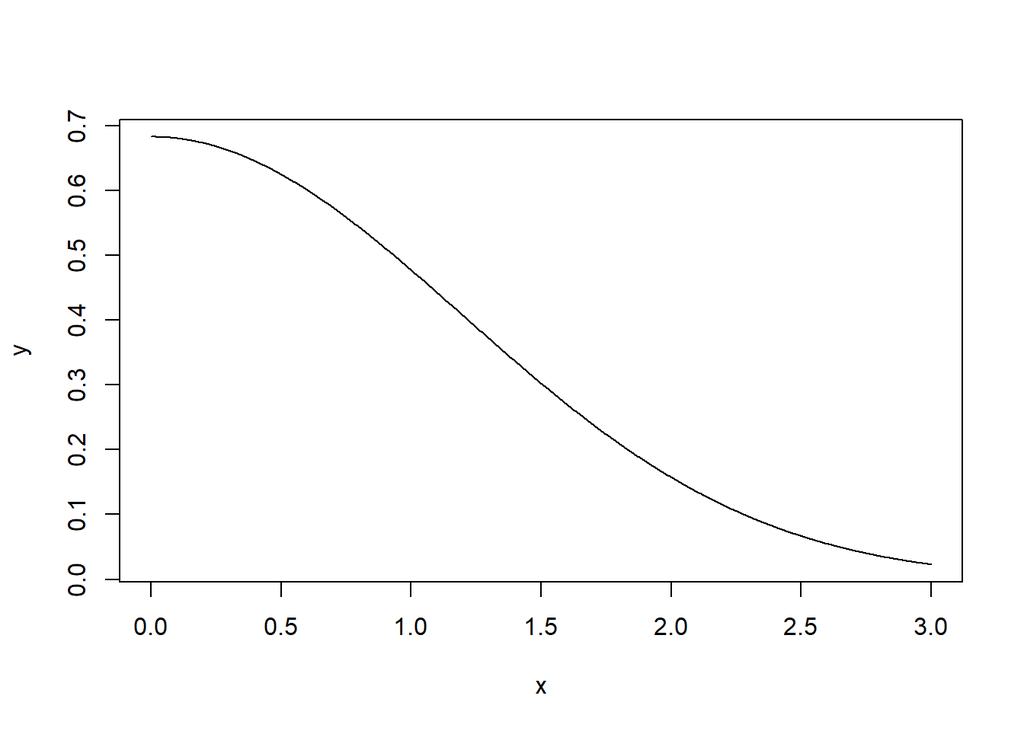

```r
x <- seq(0, 3, length=1000)
y <- pnorm(1+x)-pnorm(x-1)
plot(x, y, type="l", lwd=1)
```

# 30)

$(Y-1.96,Y+1.96)$

Here $\mu$ is considered unknown.

# 31-a)

Y=|X|

This is called a folded normal distribution. https://en.wikipedia.org/wiki/Folded_normal_distribution

$cdf(Y)=P(|X|<y)=P(-y\le X\le y)=\Phi(\frac{y-\mu}{\sigma})-\Phi(\frac{-y-\mu}{\sigma})$

# 31-b)

$(\phi(\frac{y-\mu}{\sigma})+\phi(\frac{-y-\mu}{\sigma}))\frac{1}{\sigma}$

# 31-c)

Its not continuous at 0 because its 0 for x<0. However this is not a problem to find probabilities.

for x>0 it looks like this

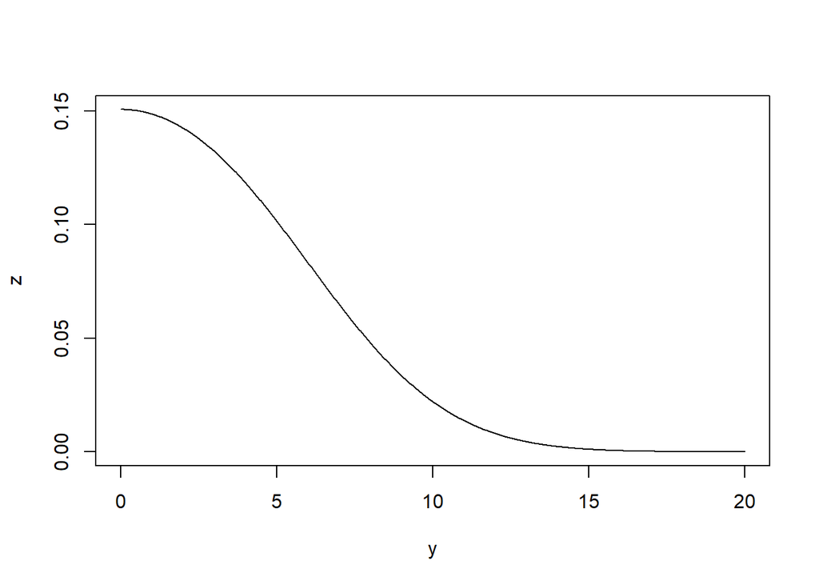

```r
y <- seq(0, 20, length=1000)
z<-(dnorm((y-1)/2,mean=1,sd=2)+dnorm((-y-1)/2,mean=1,sd=2))/2
plot(y, z, type="l", lwd=1)
```

# 32)

$P(SZ<x)=P(SZ \le x|S=1)P(S=1)+P(-x\le SZ |S=-1)P(S=-1)$

$= P(Z \le x)$ => its N(0,1)

# 33)

$\Phi(Z)$ is a symmetric (wrt y=0.5) function from (-infinity, +infinity) to (0,1)

so 0.5 must be the expectation

Also by universality of uniform $\Phi(Z)\sim Unif(0,1)$ So $E(\Phi(Z))=1/2$

# 34-a)

$P(1\le X\le 4)$ corresponds to the region

X being in (-2,-1) U (1,2)

this is $\phi(2)-\phi(1)+\phi(-1)+\phi(-2)$

so $2(\phi(2)-\phi(1))=(0.95-0.68)$

# 34-b)

$E(I(Z\gt t))\le \frac{1}{t}E(ZI(X\gt t))$

$\frac{1}{t}E(ZI(X\gt t))$ $=\frac{1}{t}\int_{\infty}^{\infty}zI(z>t)\phi(z)dz$ $=\frac{1}{t}\int_{t}^{\infty}z\phi(z)dz$

let $u=z^2/2$

then its possible to find the antiderivative of

$z\phi(z)$

$\int z\phi(z)dz=\int ze^{-z^2/2}dz=\int e^{-u}du=-e^{-u}+C=-e^{-x^2/2}+C$

So

$P(Z>t)\le \frac{1}{\sqrt{2\pi}t}\phi(t)$

So

$P(Z>t)\le \frac{1}{t}\phi(t)$

So

$1-\frac{1}{t}\phi(t)\le \Phi(t)$

# 35-a)

based on pdf o Z

$\int_{-\infty}^{+\infty} z^4 \phi(z) dz$

$=\frac{1}{\sqrt{2\pi}}\int_{-\infty}^{+\infty} z^4 e^{-z^2/2} dz$

based on pdf o Z^2

$\frac{1}{\sqrt{2\pi}}\int_{-\infty}^{+\infty} \frac{1}{\sqrt{w}}w^2e^{-w/2}dw$

# 35-b)

$E(Z^2)=Var(Z)+E^2(Z)=1$

$E(Z)=0$

$E(\Phi(Z))=1/2$ by univ. of unif

# 35-c)

$P(Z^2\le z)=P(-z\le Z\le z)=\Phi(z)-\Phi(-z)$

# 36)

$E(ZI_{Z>0})=\int_{-\infty}^{+\infty}zI_{z>0}\phi(z)dz$

$=\int_{0}^{+\infty}z\phi(z)dz=\frac{1}{\sqrt{2\pi}}e^{-z^2/2} \rvert_{0}^{\infty}=\frac{1}{\sqrt{2\pi}}$

$E((ZI_{Z>0})^2)=\int_{0}^{+\infty}z^2\phi(z)dz=\sqrt{2\pi}/2$

its in the book p214

# 37) TODO

# 38) TODO

# 39)

$X,Y,Z \sim Expo(1/6)$

Earliest time when all 3 complete is the max of X,Y,Z

eg:

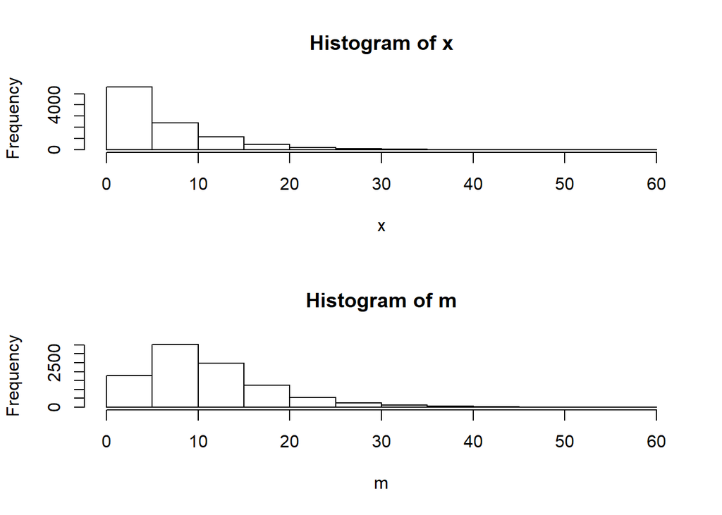

```r
x<- rexp(10000,1/6)
y<- rexp(10000,1/6)
z<- rexp(10000,1/6)
m<- pmax(x,y,z)

par(mfrow=c(2,1))
hist(x)
hist(m)
```

```r
mean(m)
```

```
## [1] 10.96709
```

Curious!

To find the cdf:

$P(max(X,Y,Z)\le w)=P(X\le w\land Y\le w\land Z\le w )$ $=P(X\le w)P(Y\le w)P(Z\le w)$ $=(1-e^{-\lambda x})^3$

This will get complicated..

So try another route. We know from the book that minimum of n iid $Expo(\lambda)$s is $Expo(n\lambda)$

$E(max(X,Y,Z))=E(A+B+C)$

where A is the time for the minimum of 3 to happen B, the minimum of 2 to happen C, the minimum of 1 to happen

So

$=E(A)+E(B)+E(C)=1/3\lambda+1/2\lambda+1/\lambda$ $=11/6\lambda$

with $\lambda=1/6$ this gives 11 agreeing the simulation above.

By direct calculation

https://m.wolframalpha.com/input/?i=integral+1%2F2x%28e%5E%28-x%2F2%29%29%28e%5E%28x%2F6%29-1%29%5E2+from+0+to+infinity

# 40-a)

$P(T<x)=F(x)=0.5$

$x=F^{-1}(0.5)$

$F^{-1}(x)=-\frac{log(1-x)}{\lambda}$

$F^{-1}(0.5)=-\frac{log(0.5)}{\lambda}$

# 40-b)

$\frac{F(t+\epsilon)-F(t)}{1-F(t)}$

$=\frac{(1-e^{-\lambda (t+\epsilon)})-(1-e^{-\lambda t})}{1-(1-e^{-\lambda t})}$

$=\frac{e^{-\lambda t}-e^{-\lambda (t+\epsilon)}}{e^{-\lambda t}}$

$=1-e^{-\lambda \epsilon}$

Since for $x\approx 0$ we have $e^{x}\approx 1+x$

$e^{-x}\approx 1-x$

So

$=1-e^{-\lambda \epsilon}=1-(1-\epsilon)=\epsilon$

# 40-c)

$min(T_i)\sim Expo(n\lambda)$ for $T_i\sim Expo(\lambda)$

# 40-d)

Similar to what we did on 39

# 41-a)

The probability that an offer is more than 15000 is

```r
1-pexp(15000,rate=10^-4)
```

```
## [1] 0.2231302
```

https://m.wolframalpha.com/input/?i=sum+%281%2Bi%29p%281-p%29%5Ei+from+i%3D0+to+infinity%2C+p%3D0.2231302

This is the mean of the First Success distribution with p=

```r
1-pexp(15000,rate=10^-4)
```

```
## [1] 0.2231302
```

# 41-b)

so 15000+10000 is the expected sale price

# 42-a)

10

# 42-b)

Distribution example:

Consider:

| min | probability |
| --- | --- |
| 1 | 90/99 |
| 100 | 9/99 |

here bus to bus mean is 10

But Fred to bus mean is (1/101)+(100/101)100

because Fred 100 times more likely to arrive at a 100 min interarrival duration then a 1 min one.

# 43-a)

TODO

# 43-b)

Lets try a simulation

Say, Route 1 is Pois(7)

Route 2 is Pois(3)

and

n=5

```r
results<-replicate(10^4,all(cumsum(rexp(5,7))<rexp(1,3)))

sum(results)/10^4
```

```
## [1] 0.1639
```

```r
(7/(7+3))^5
```

```
## [1] 0.16807
```